# 20160613DataAnalysisWIthR

# Lesson 3

### What to Do First?

Notes:

### Pseudo-Facebook User Data

Notes:

### Histogram of Users’ Birthdays

Notes:

```r
#install.packages('ggplot2')
library(ggplot2)
getwd()
```

```
## [1] "D:/P/3Language/Xiaolong/python/XCProject/Udacity/R_study"
```

```r
setwd('E:\\Study\\coursera\\Udacity\\ud651DataAnalysisWithR\\')
pf = read.csv('pseudo_facebook.tsv', sep = '\t')
names(pf)
```

```
##  [1] "userid"                "age"
##  [3] "dob_day"               "dob_year"
##  [5] "dob_month"             "gender"
##  [7] "tenure"                "friend_count"
##  [9] "friendships_initiated" "likes"
## [11] "likes_received"        "mobile_likes"
## [13] "mobile_likes_received" "www_likes"
## [15] "www_likes_received"
```

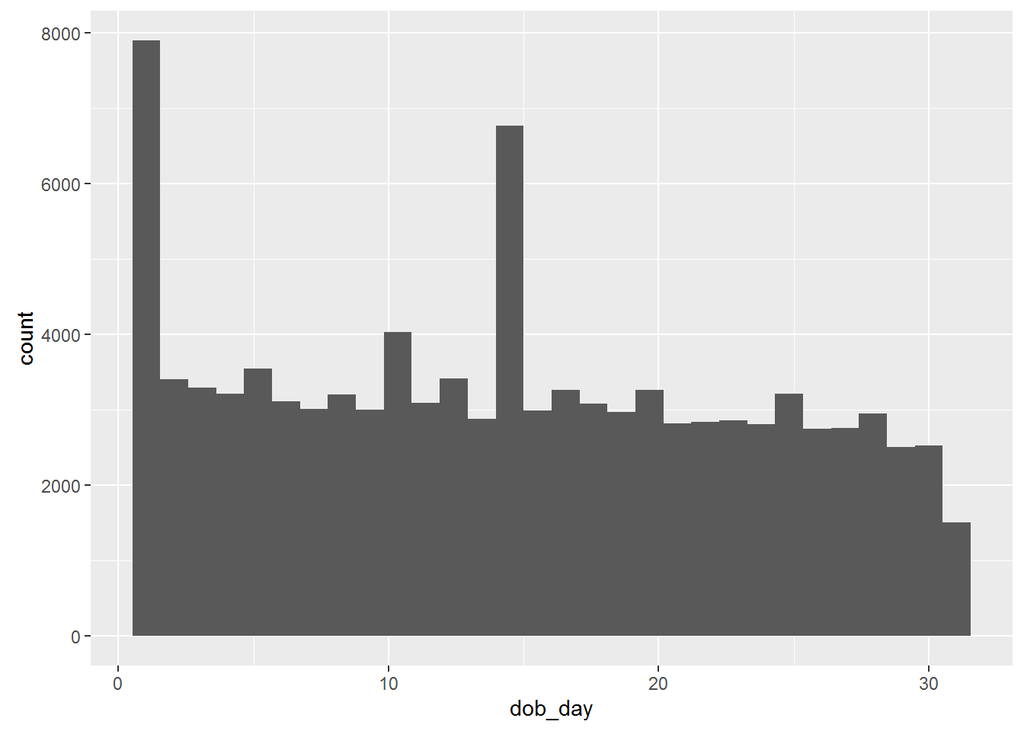

```r
qplot(x = dob_day, data = pf)
```

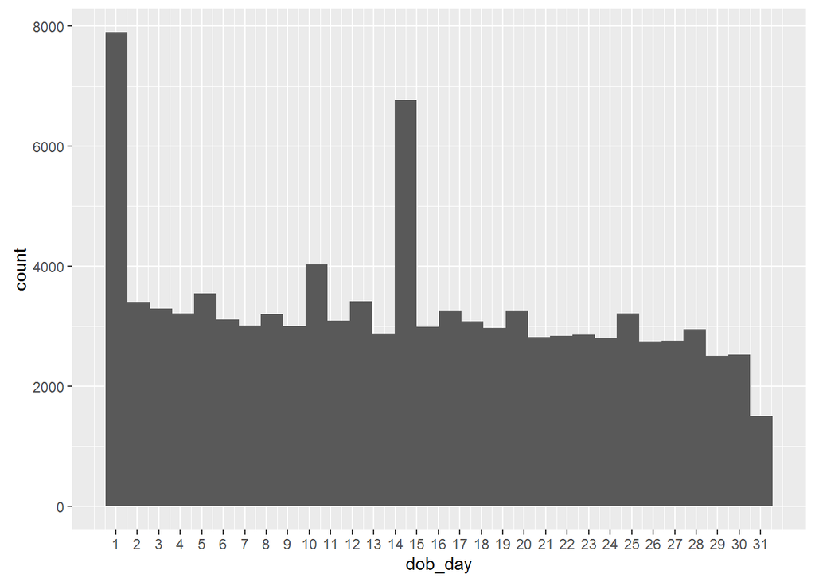

```r
qplot(x = dob_day, data = pf) + scale_x_continuous(breaks = 1:31)
```

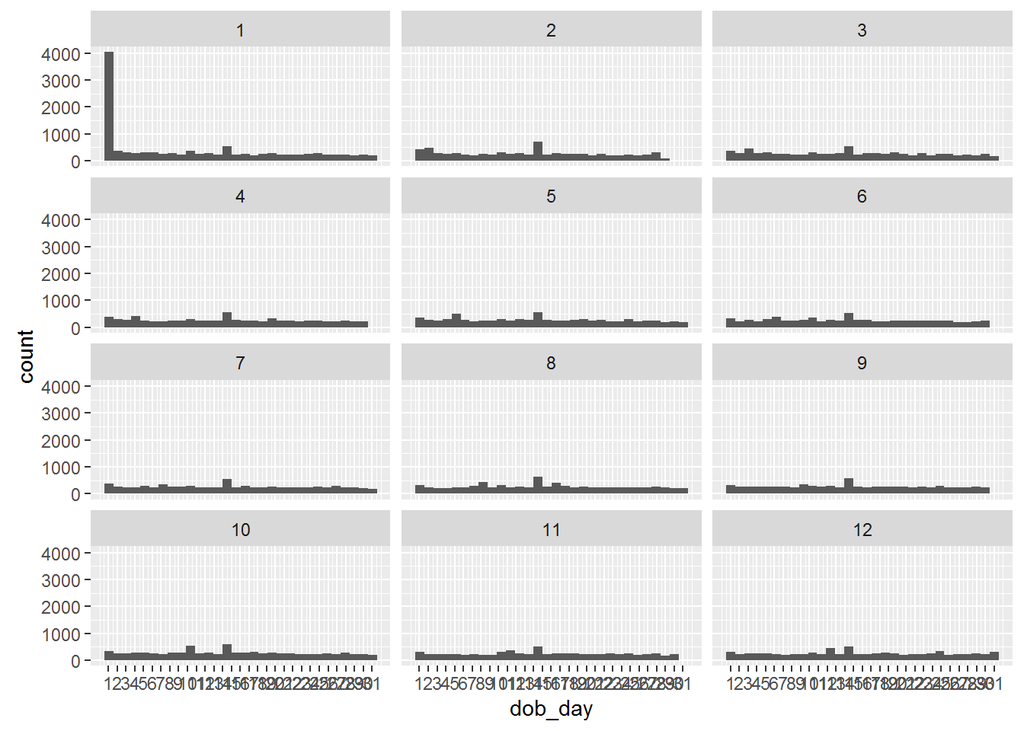

```r
qplot(x = dob_day, data = pf) + scale_x_continuous(breaks = 1:31) +
  facet_wrap(~dob_month, ncol = 3)
```

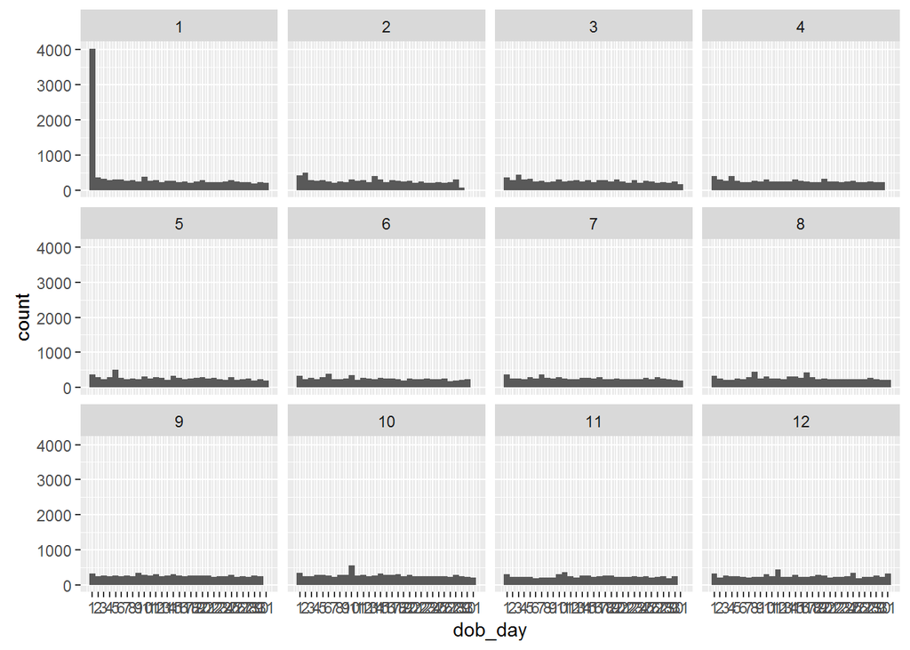

```r
ggplot(data = pf, aes(x = dob_day)) + geom_histogram(binwidth = 1) +
  scale_x_continuous(breaks = 1:31) + facet_wrap(~dob_month)
```

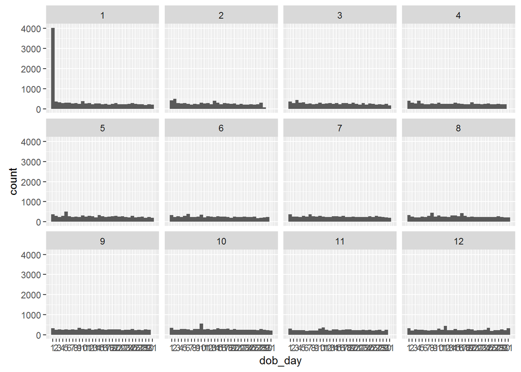

```r
ggplot(data = pf, aes(x = dob_day)) + geom_histogram(binwidth = 1) +
  scale_x_continuous(breaks = 1:31) + facet_wrap(~dob_month)
```

#### What are some things that you notice about this histogram?

Response:

### Moira’s Investigation

Notes:

### Estimating Your Audience Size

Notes:

#### Think about a time when you posted a specific message or shared a photo on Facebook. What was it?

Response:

#### How many of your friends do you think saw that post?

Response:

#### Think about what percent of your friends on Facebook see any posts or comments that you make in a month. What percent do you think that is?

Response:

### Perceived Audience Size

Notes:

### Faceting

Notes:

#### Let’s take another look at our plot. What stands out to you here?

Response:

### Be Skeptical - Outliers and Anomalies

Notes:

### Moira’s Outlier

Notes: #### Which case do you think applies to Moiras outlier? Response:

### Friend Count

Notes:

#### What code would you enter to create a histogram of friend counts?

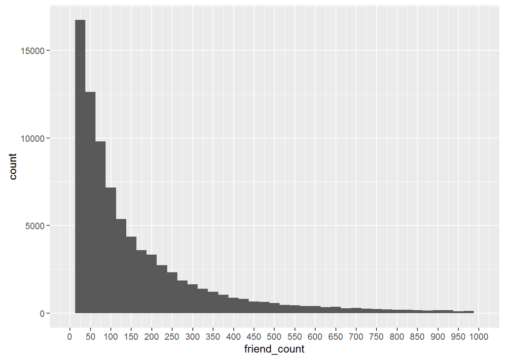

```r
ggplot(data = pf, aes(x = friend_count)) + geom_histogram()
ggplot(data = pf, aes(x = friend_count)) + geom_histogram() + scale_x_continuous(limits = c(0,1000))
qplot(x = friend_count, data = pf)
qplot(x = friend_count, data = pf, xlim = c(0,1000))
qplot(x = friend_count, data = pf) + scale_x_continuous(limits = c(0,1000))
qplot(x = friend_count, data = pf, binwidth = 25) +
  scale_x_continuous(limits = c(0,1000), breaks = seq(0,1000,50))
```

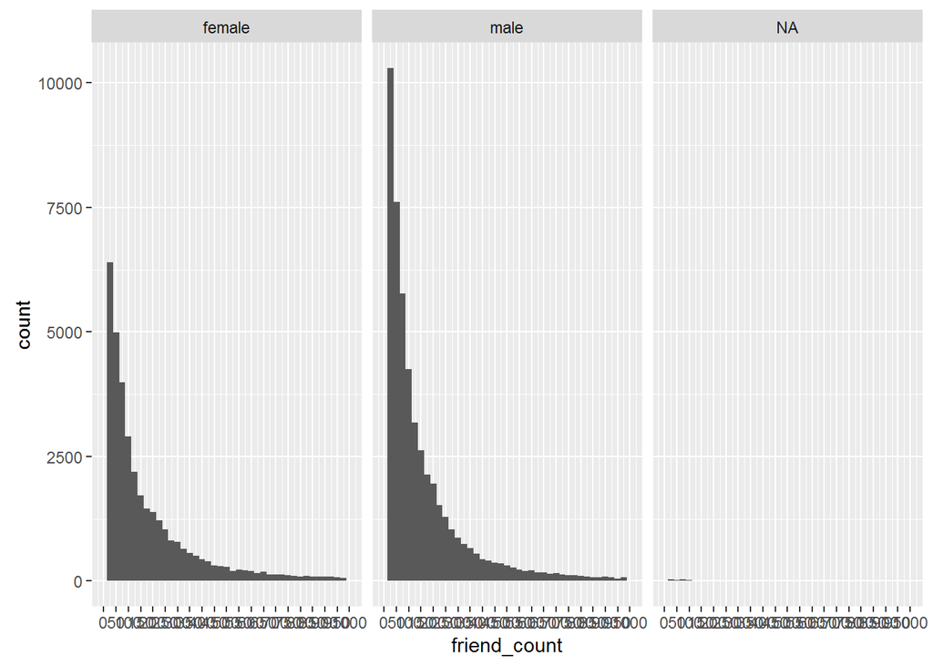

```r
qplot(x = friend_count, data = pf, binwidth = 25) +
  scale_x_continuous(limits = c(0,1000), breaks = seq(0,1000,50)) +
  facet_wrap(~gender) #split based on gender
```

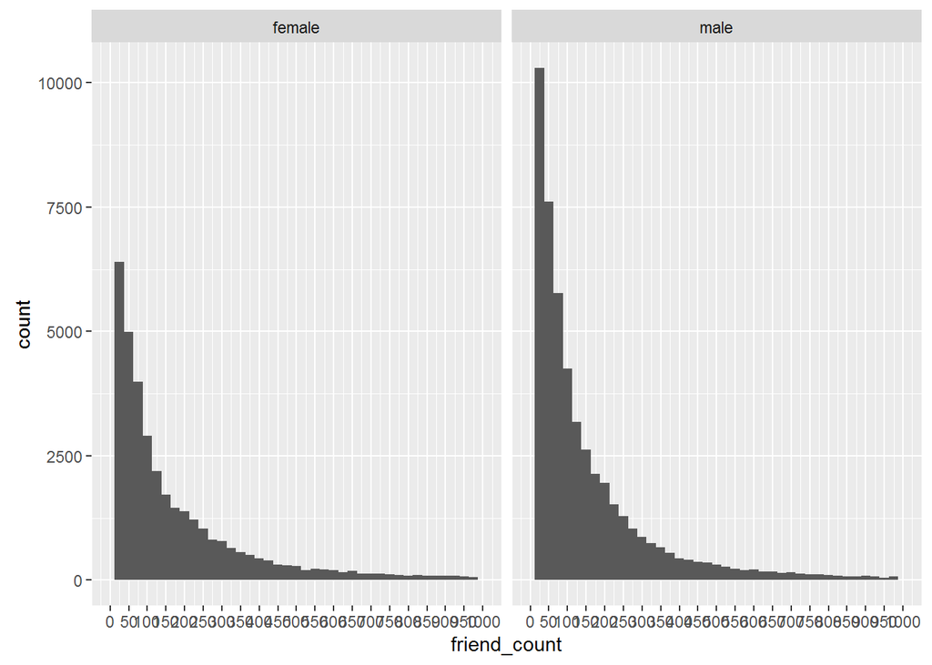

```r
qplot(x = friend_count, data = subset(pf, !is.na(gender)), binwidth = 25) +
  scale_x_continuous(limits = c(0,1000), breaks = seq(0,1000,50)) +
  facet_wrap(~gender) #split based on gender. use subset function to remove na in gender
```

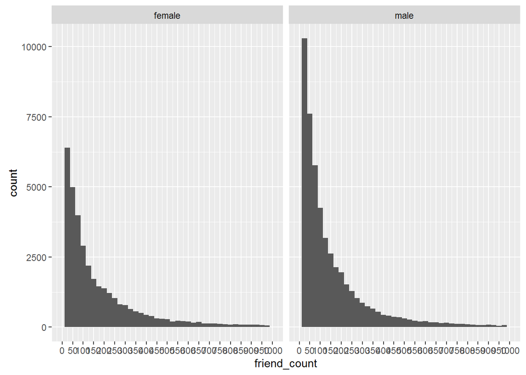

```r
qplot(x = friend_count, data = na.omit(pf), binwidth = 25) +
  scale_x_continuous(limits = c(0,1000), breaks = seq(0,1000,50)) +
  facet_wrap(~gender) #split based on gender. any observation with na will be removed with na.omit
```

#### How is this plot similar to Moira’s first plot?

Response:

### Limiting the Axes

Notes:

### Exploring with Bin Width

Notes:

### Adjusting the Bin Width

Notes:

### Faceting Friend Count

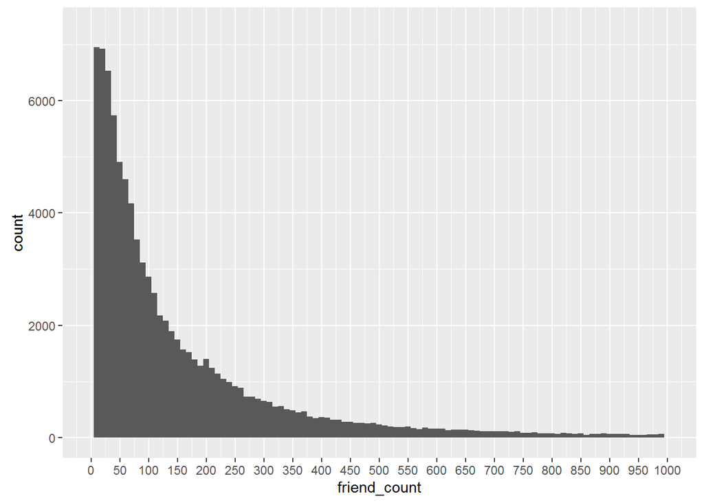

```r
# What code would you add to create a facet the histogram by gender?
# Add it to the code below.
qplot(x = friend_count, data = pf, binwidth = 10) +
  scale_x_continuous(limits = c(0, 1000),
                     breaks = seq(0, 1000, 50))
```

### Omitting NA Values

Notes:

### Statistics ‘by’ Gender

Notes:

```r
table(pf$gender)
```

```
##
## female   male
##  40254  58574
```

```r
by(pf$friend_count,pf$gender,summary)
```

```
## pf$gender: female
##    Min. 1st Qu.  Median    Mean 3rd Qu.    Max.
##       0      37      96     242     244    4923
## --------------------------------------------------------
## pf$gender: male
##    Min. 1st Qu.  Median    Mean 3rd Qu.    Max.
##       0      27      74     165     182    4917
```

#### Who on average has more friends: men or women?

Response:

#### What’s the difference between the median friend count for women and men?

Response:

#### Why would the median be a better measure than the mean?

Response:

### Tenure

Notes:

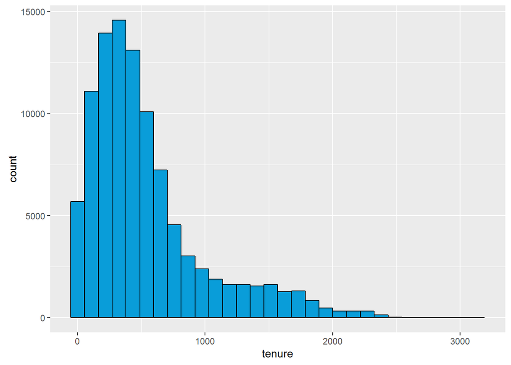

```r
qplot(x = tenure, data = pf, color = I('black'), fill = I('#099DD9'))
```

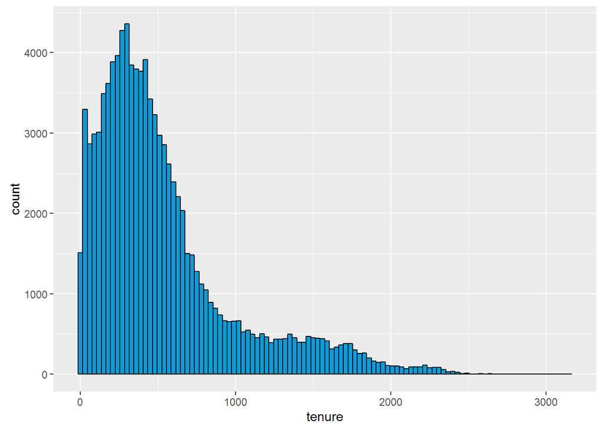

```r
qplot(x = tenure, data = pf, color = I('black'), fill = I('#099DD9'), binwidth = 30)
```

#### How would you create a histogram of tenure by year?

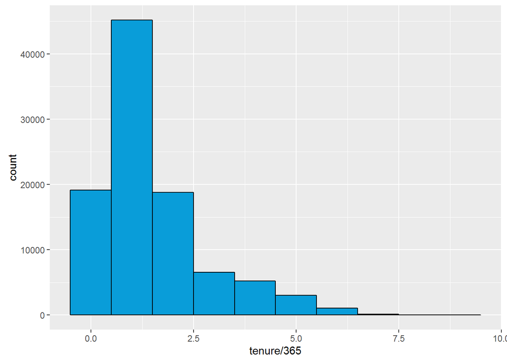

```r
qplot(x = tenure/365, data = pf, color = I('black'), fill = I('#099DD9'), binwidth = 1)
```

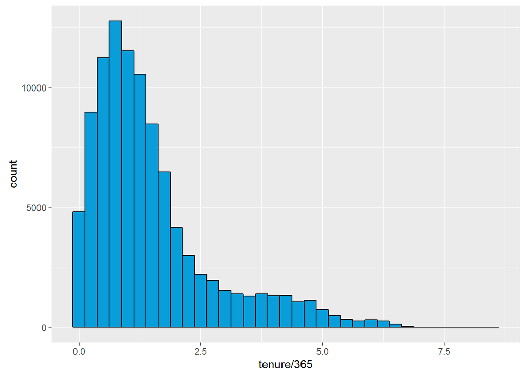

```r
qplot(x = tenure/365, data = pf, color = I('black'), fill = I('#099DD9'), binwidth = 0.25)
```

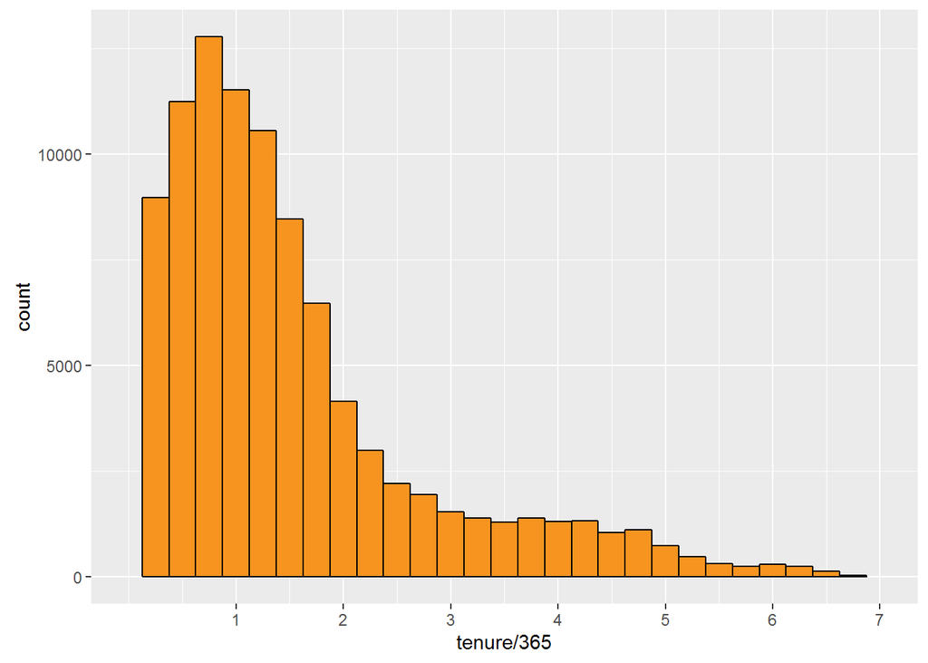

```r
qplot(x = tenure/365, data = pf, color = I('black'), fill = I('#F79420'), binwidth = 0.25) +
  scale_x_continuous(breaks = seq(1,7,1), limits = c(0,7))
```

### Labeling Plots

Notes:

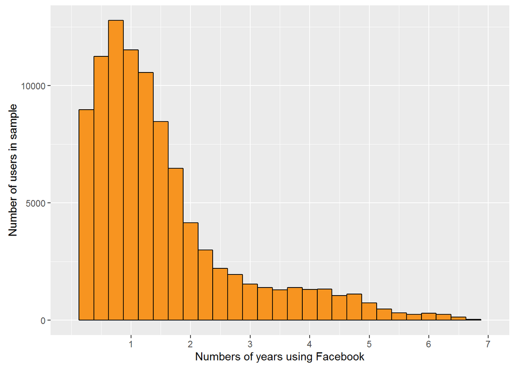

```r
qplot(x = tenure/365, data = pf, color = I('black'),
      fill = I('#F79420'), binwidth = 0.25,
      xlab = 'Numbers of years using Facebook',
      ylab = 'Number of users in sample') +
  scale_x_continuous(breaks = seq(1,7,1), limits = c(0,7))
```

### User Ages

Notes:

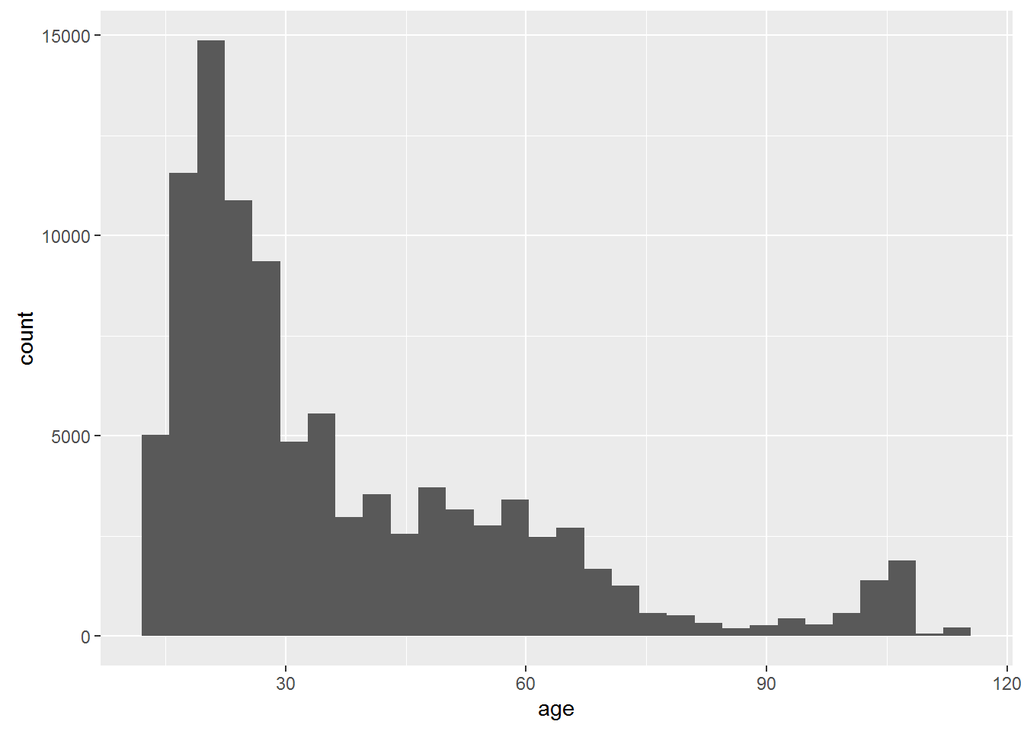

```r
qplot(x = age, data = pf)
```

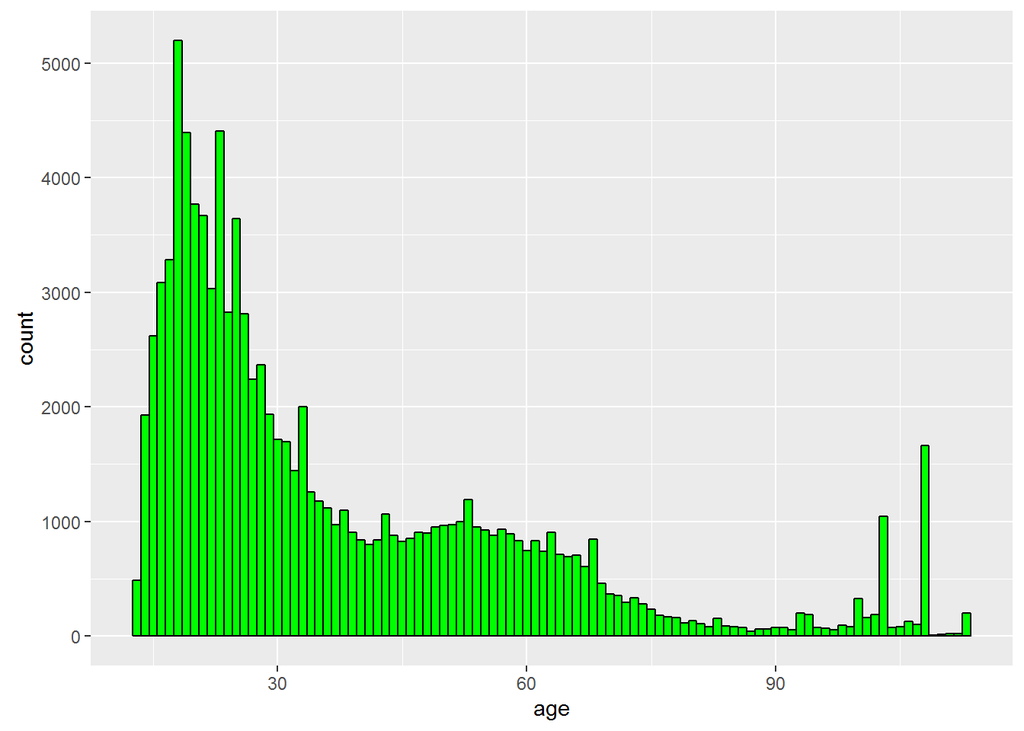

```r
qplot(x = age, data = pf, binwidth = 1, color = I('black'), fill = I('#00FF00'))
```

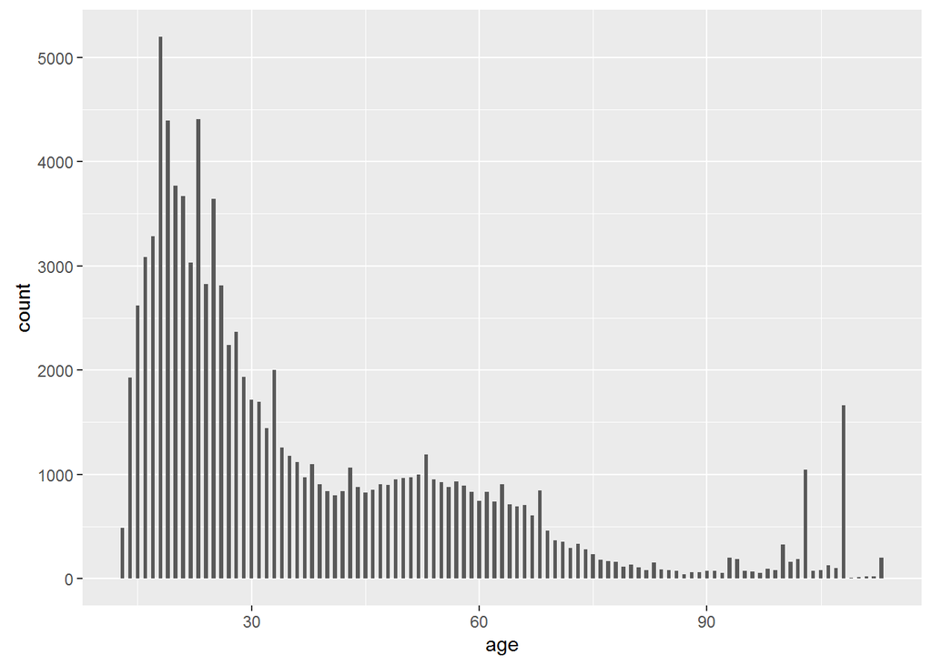

```r
qplot(x = age, data = pf, binwidth = 0.5)
```

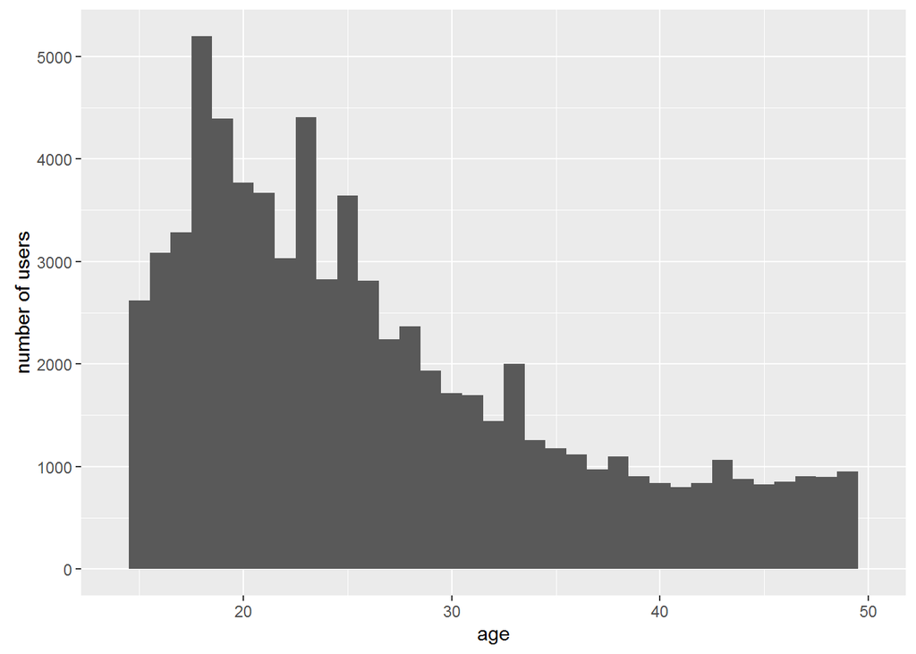

```r
qplot(x = age, data = pf, binwidth = 1,
      xlab = 'age',
      ylab = 'number of users') +
  scale_x_continuous(limits = c(14,50))
```

```r
summary(pf$age)
```

```
##    Min. 1st Qu.  Median    Mean 3rd Qu.    Max.
##   13.00   20.00   28.00   37.28   50.00  113.00
```

#### What do you notice?

Response:

### The Spread of Memes

Notes:

### Lada’s Money Bag Meme

Notes:

### Transforming Data

Notes:

### Add a Scaling Layer

Notes:

```r
qplot(x = friend_count, data = pf)
summary(pf$friend_count)
```

```
##    Min. 1st Qu.  Median    Mean 3rd Qu.    Max.
##     0.0    31.0    82.0   196.4   206.0  4923.0
```

```r
summary(log10(pf$friend_count+1))
```

```
##    Min. 1st Qu.  Median    Mean 3rd Qu.    Max.
##   0.000   1.505   1.919   1.868   2.316   3.692
```

```r
summary(sqrt(pf$friend_count))
```

```
##    Min. 1st Qu.  Median    Mean 3rd Qu.    Max.
##   0.000   5.568   9.055  11.090  14.350  70.160
```

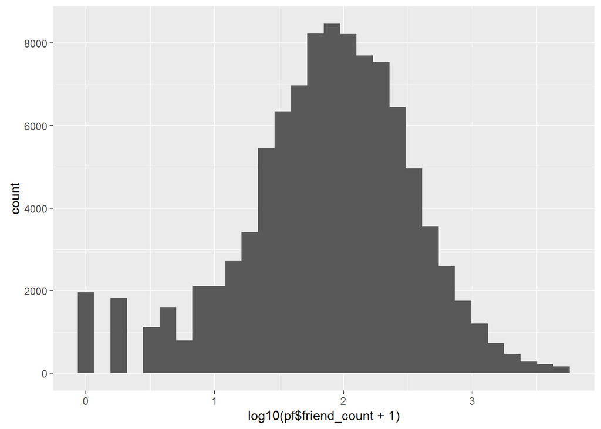

```r
#install.packages('gridExtra')
library(gridExtra)

qplot(x = log10(pf$friend_count+1), data = pf)
```

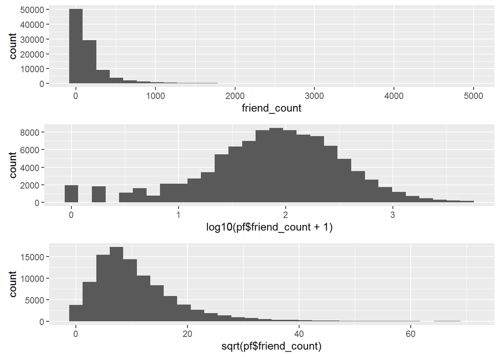

```r
p1 = qplot(x = friend_count, data = pf)
p2 = qplot(x = log10(pf$friend_count+1), data = pf)
p3 = qplot(x = sqrt(pf$friend_count), data = pf)
grid.arrange(p1,p2,p3,ncol = 1)
```

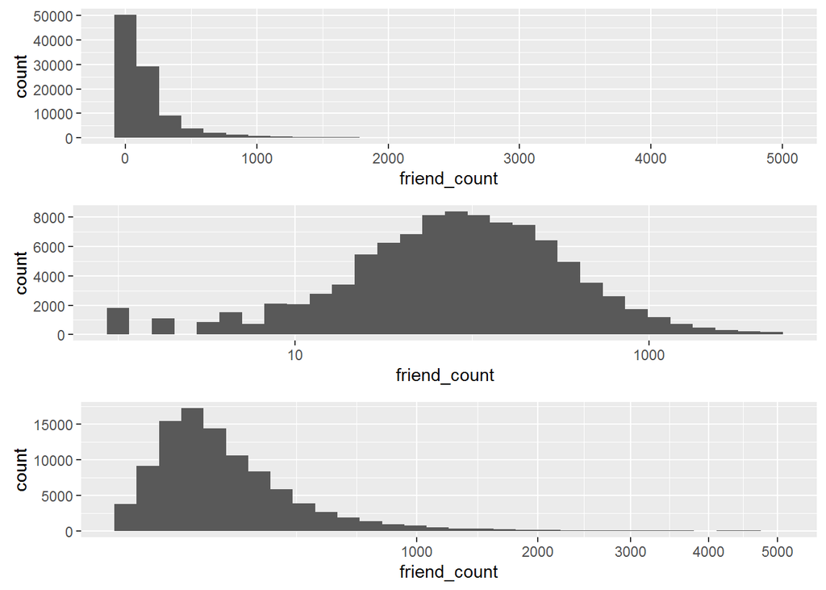

```r
p4 = ggplot(aes(x = friend_count), data = pf) + geom_histogram()
p5 = p4 + scale_x_log10()
p6 = p4 + scale_x_sqrt()
grid.arrange(p4,p5,p6, ncol = 1)
```

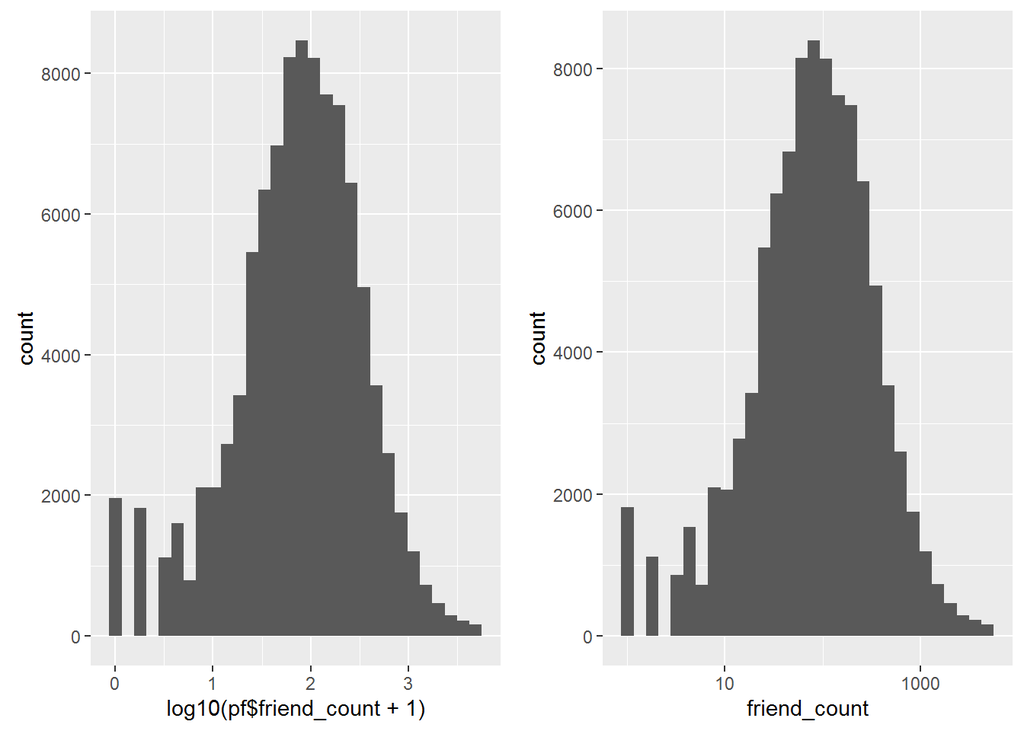

```r
grid.arrange(p2,p5,ncol = 2)
```

### Frequency Polygons

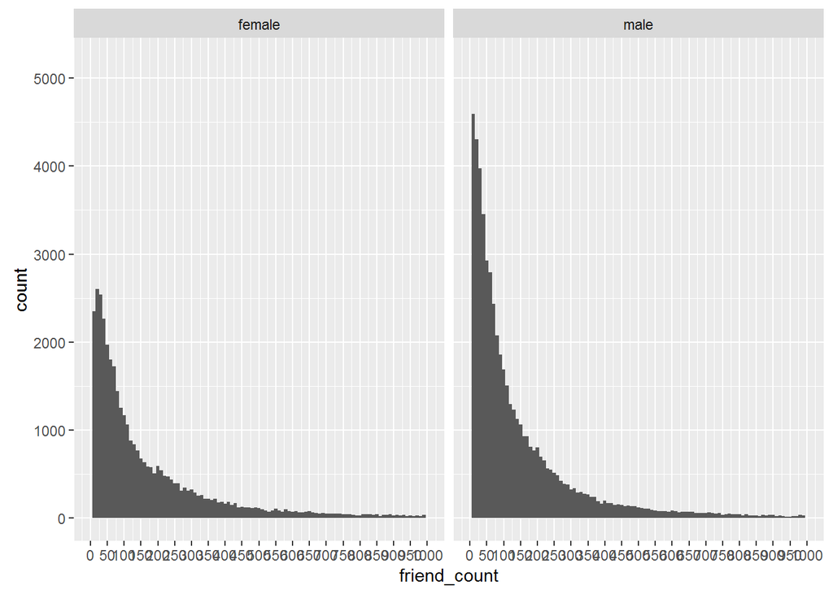

```r
qplot(x = friend_count, data = subset(pf, !is.na(gender)),
      binwidth = 10) +
  scale_x_continuous(lim = c(0,1000), breaks = seq(0,1000,50)) +
  facet_wrap(~gender)
```

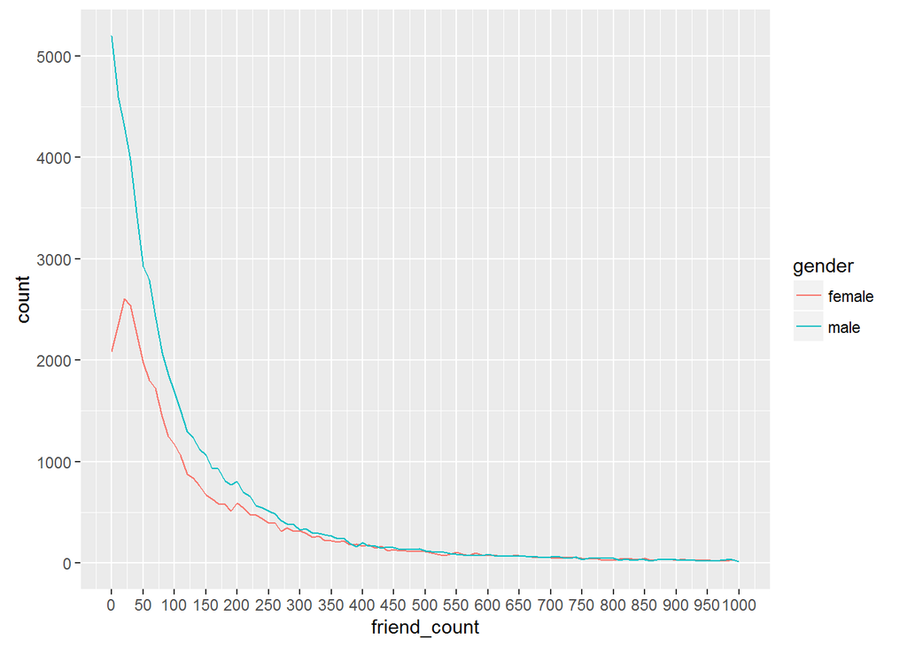

```r
qplot(x = friend_count,  data = subset(pf, !is.na(gender)),
      binwidth = 10, geom = 'freqpoly', color =gender) +
  scale_x_continuous(lim = c(0,1000), breaks = seq(0,1000,50))
```

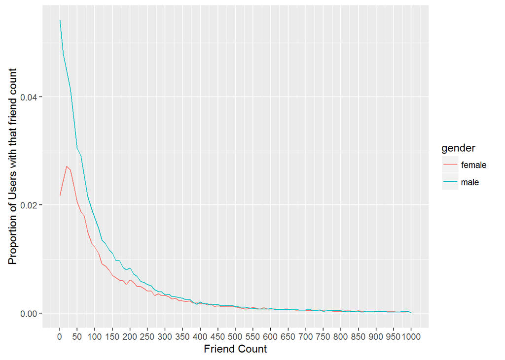

```r
qplot(x = friend_count, y = ..count../sum(..count..), data = subset(pf, !is.na(gender)),
      binwidth = 10, geom = 'freqpoly', color =gender,
      xlab = 'Friend Count',
      ylab = 'Proportion of Users with that friend count') +
  scale_x_continuous(lim = c(0,1000), breaks = seq(0,1000,50))
```

### Likes on the Web

Notes:

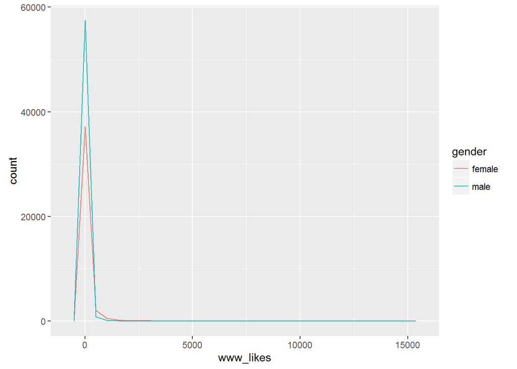

```r
p8 = qplot(x = www_likes,  data = subset(pf, !is.na(gender)),
       geom = 'freqpoly', color =gender) +
  scale_x_continuous()
p8
```

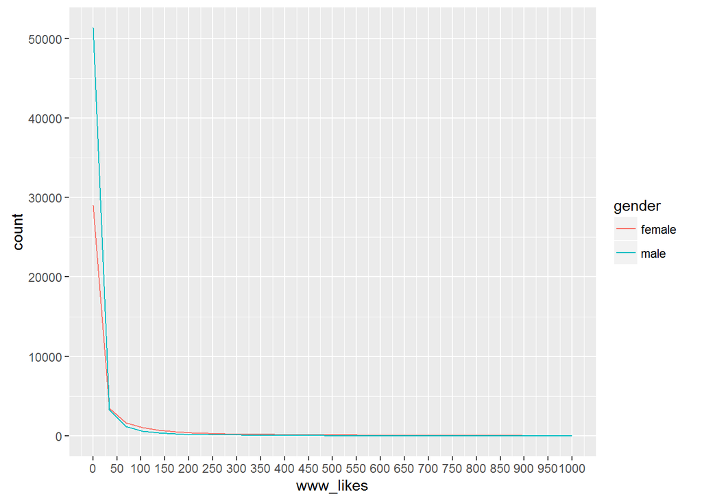

```r
p9 = p8 + scale_x_continuous(lim = c(0,1000), breaks = seq(0,1000,50))
p9
```

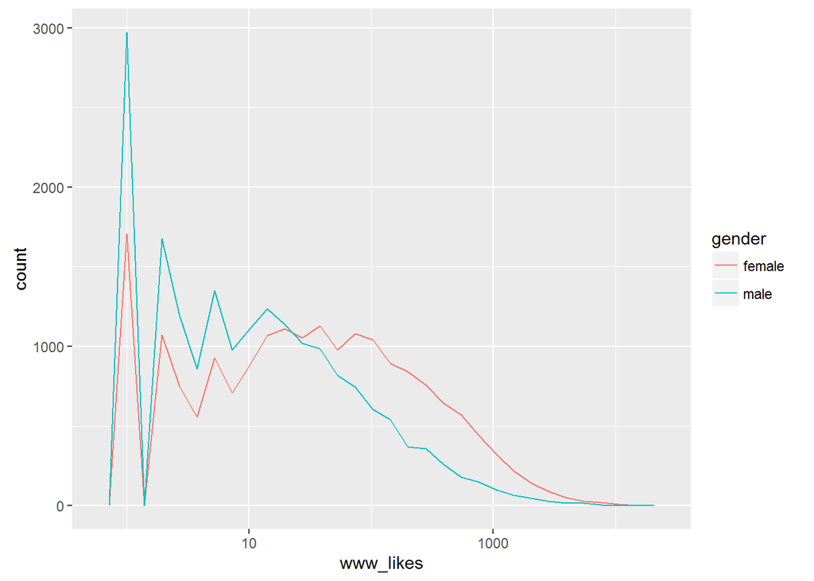

```r
p10 = p8 + scale_x_log10()
p10
```

```r
by(pf$www_likes, pf$gender, summary)
```

```
## pf$gender: female
##     Min.  1st Qu.   Median     Mean  3rd Qu.     Max.
##     0.00     0.00     0.00    87.14    25.00 14860.00
## --------------------------------------------------------
## pf$gender: male
##     Min.  1st Qu.   Median     Mean  3rd Qu.     Max.
##     0.00     0.00     0.00    24.42     2.00 12900.00
```

```r
by(pf$www_likes, pf$gender, sum)
```

```
## pf$gender: female
## [1] 3507665
## --------------------------------------------------------
## pf$gender: male
## [1] 1430175
```